# Data Visualization with Modern Data Science

> Introduction

Kuo, Yao-Jen

## TL; DR

> In this lecture, we talk about the "what and why" about visualization and modern data science. Moreover, a brief introduction to the tools we will cover in the coming courses: Tableau, SQL, and Python.

## What is visualization

> Visualization is a tool that addresses the gap between data, function, formula, and viewers. Effective visualizations transform abstract collections of numbers into shapes that viewers quickly grasp and understand.

Source: [Data Visualization with JavaScript](https://www.amazon.com/Data-Visualization-JavaScript-Stephen-Thomas-ebook/dp/B00V20IFDG)

## Why visualization

## What are $x$ and $f$

```python
print(x)
print(f)
```

```
[ 0.          0.25645654  0.51291309  0.76936963  1.02582617  1.28228272
  1.53873926  1.7951958   2.05165235  2.30810889  2.56456543  2.82102197
  3.07747852  3.33393506  3.5903916   3.84684815  4.10330469  4.35976123
  4.61621778  4.87267432  5.12913086  5.38558741  5.64204395  5.89850049
  6.15495704  6.41141358  6.66787012  6.92432667  7.18078321  7.43723975
  7.69369629  7.95015284  8.20660938  8.46306592  8.71952247  8.97597901
  9.23243555  9.4888921   9.74534864 10.00180518 10.25826173 10.51471827
 10.77117481 11.02763136 11.2840879  11.54054444 11.79700098 12.05345753
 12.30991407 12.56637061]
[ 0.00000000e+00  2.53654584e-01  4.90717552e-01  6.95682551e-01
  8.55142763e-01  9.58667853e-01  9.99486216e-01  9.74927912e-01
  8.86599306e-01  7.40277997e-01  5.45534901e-01  3.15108218e-01
  6.40702200e-02 -1.91158629e-01 -4.33883739e-01 -6.48228395e-01
 -8.20172255e-01 -9.38468422e-01 -9.95379113e-01 -9.87181783e-01
 -9.14412623e-01 -7.81831482e-01 -5.98110530e-01 -3.75267005e-01
 -1.27877162e-01  1.27877162e-01  3.75267005e-01  5.98110530e-01
  7.81831482e-01  9.14412623e-01  9.87181783e-01  9.95379113e-01
  9.38468422e-01  8.20172255e-01  6.48228395e-01  4.33883739e-01
  1.91158629e-01 -6.40702200e-02 -3.15108218e-01 -5.45534901e-01
 -7.40277997e-01 -8.86599306e-01 -9.74927912e-01 -9.99486216e-01
 -9.58667853e-01 -8.55142763e-01 -6.95682551e-01 -4.90717552e-01
 -2.53654584e-01 -4.89858720e-16]
```

## $f(x)=sin(x), \text{where } 0 \leq x \leq 4\pi$

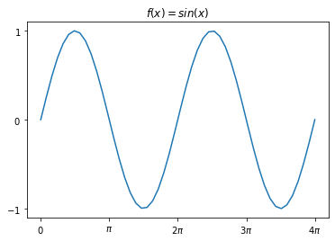

```python
plot_sinx(x, f)
```

## What does the following formula stand for

$$S(x) = \frac{1}{1 + e^{-x}}$$

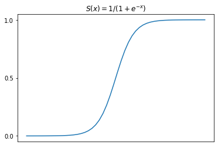

```python
plot_sigmoid(x, S)
```

## Visualization also plays a key role in machine learning

## Machine learning engineer uses line plot to visualize cost function

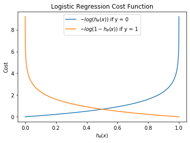

```python
plot_logistic_cost_function(x)
```

## Machine learning engineer uses surface plot to visualize gradients

[figure not shown]

Source: [Coursera | Machine Learning](https://www.coursera.org/learn/machine-learning)

## Machine learning engineer also uses contour plot to visualize gradients

[figure not shown]

Source: [Coursera | Machine Learning](https://www.coursera.org/learn/machine-learning)

## Machine learning engineer uses scatter plot and contour plot to visualize decision boundary

Source: https://scikit-learn.org/stable/auto_examples/ensemble/plot_voting_decision_regions.html#sphx-glr-auto-examples-ensemble-plot-voting-decision-regions-py

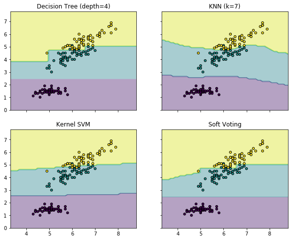

```python
plot_multiple_decision_boundary()
```

## The 2 most influential visualizations of ALL TIME

1. [Minard's map of Napoleon's disastrous Russian campaign of 1812](https://en.wikipedia.org/wiki/Flow_map#/media/File:Minard.png)
2. [Hans Rosling's 200 Countries, 200 Years, 4 Minutes](https://youtu.be/jbkSRLYSojo)

## [Minard's map of Napoleon's disastrous Russian campaign of 1812](https://en.wikipedia.org/wiki/Flow_map#/media/File:Minard.png)

In 1812, Napoleon marched to Moscow. 98% of his soldiers died. The simple but fascinating temperature line below the viz shows how cold ultimately defeated Napoleon’s army.

[figure not shown]

## [Hans Rosling's 200 Countries, 200 Years, 4 Minutes](https://youtu.be/jbkSRLYSojo)

A 2007 TED talk for the Swedish scientist shared his passion with the world. It shows the relationship between wealth and health.

[figure not shown]

> The simple graph has brought more information to the data analyst’s mind than any other device.

> [John Tukey](https://en.wikipedia.org/wiki/John_Tukey)

## [John Tukey](https://en.wikipedia.org/wiki/John_Tukey) is an American mathematician best known for development of box plot.

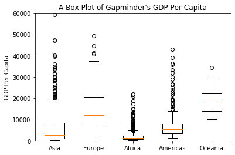

```python
plot_box_plot(gapminder)
```

## What is modern data science

> Modern data science is a huge field, it invovles applications and tools like importing, tidying, transformation, visualization, modeling, and communication. Surrounding all these is programming.

[figure not shown]

Source: [R for Data Science](https://r4ds.had.co.nz/)

[figure not shown]

Source: https://twitter.com/cdixon/status/428914681911070720/photo/1

[figure not shown]

Source: http://drewconway.com/

## Meet my favorite data scientist on TV show: Chandler Bing

[figure not shown]

Source: https://gph.is/g/4DA0wGO

[figure not shown]

Source: https://www.warnerbros.com/tv/friends/

[figure not shown]

Source: https://www.warnerbros.com/tv/friends/

## Tools you're gonna use in this course

## A little bit of ...

- Text editor for flat file previews
- Tableau for **visualization** and **communication**
- SQL for **importing**
- Python for **importing**, **tidying**, and **transformation**

## In fact, Python(or R, Julia, ...etc.) is capable to tackle everything

[figure not shown]

Source: [R for Data Science](https://r4ds.had.co.nz/)

## So apparently, we will only use a tiny little bit of Python's mighty features

## What is a text editor

> A text editor is a type of computer program that edits plain text. Text editors are provided with operating systems and software development packages, and can be used to change files such as configuration files, documentation files and programming language source code.

Source: https://en.wikipedia.org/wiki/Text_editor

[figure not shown]

Source: https://en.wikipedia.org/wiki/File:Archimedes_lever_(Small).jpg

## Getting reday for text editor

- Download [Visual Studio Code](https://code.visualstudio.com/)
- Do not confuse with **Visual Studio Code** with **Visual Studio**: https://stackoverflow.com/questions/30527522/what-are-the-differences-between-visual-studio-code-and-visual-studio

## What is Tableau

> Tableau is a tool that was designed to enable you to perform complex data analysis tasks and create powerful, interactive visualizations that communicate the analysis.

Source: https://www.tableau.com/

## Getting ready for Tableau

- [Download Tableau Desktop](https://mail.ntu.edu.tw/owa/redir.aspx?REF=ltICoWwfHc3XR6kg-OKD_WP9bk6Z1DRPd7-VqMapuWgjuNeE-rzXCAFodHRwczovL3d3dy50YWJsZWF1LmNvbS90ZnQvYWN0aXZhdGlvbg..)
- When prompted, enter your school email address for Business E-mail and enter the name of your school for Organization
- Activate with your product key(Product keys will be sent to your school email address)

## What is SQL

> Structured Query Language is a descriptive computer language designed for updating, retrieving, and calculating data in table-based databases.

Source: https://developer.mozilla.org/

## We are gonna use 2 RDBMS(Relational Database Management System) through out the course

- MySQL for learning Read
- SQLite for learning Create, Update, and Deletion

## What is RDBMS

> A database management system (DBMS) is a set of programs used to define, administer, and process databases and their associated applications. RDBMS is the basis for SQL, and for all modern database systems such as MS SQL Server, IBM DB2, Oracle, MySQL, and Microsoft Access.

Source: https://www.w3schools.com/sql/sql_intro.asp

## Getting ready for MySQL

- [Download MySQL Workbench](https://downloads.mysql.com/archives/workbench/)
- Go with **archived versions**

## Getting ready for SQLite

- [Download DB Browser for SQLite](https://sqlitebrowser.org/dl/)
- Go with the **latest version**

## What is Python

> Python is a clear and powerful object-oriented programming language.

Source: https://www.python.org/

## Getting ready for Python

We are using [JupyterHub](https://jupyter.org/hub), [Binder](https://mybinder.org/) or [Google Colaboratory](https://colab.research.google.com/), so practically nothing for you to prepare.

## Why Tableau, SQL, and Python, anyway

## Let's explore 3 questions in [2019 Kaggle ML & DS Survey](https://www.kaggle.com/c/kaggle-survey-2019)

- Q14: What is the primary tool that you use at work or school to analyze data?
- Q18: What programming languages do you use on a regular basis?
- Q19: What programming language would you recommend an aspiring data scientist to learn first?

## What is [Kaggle](https://kaggle.com/)

> A subsidiary of Google, is an online community of data scientists and machine learning practitioners. Kaggle allows users to find and publish data sets, explore and build models in a web-based data-science environment, work with other data scientists and machine learning engineers, and enter competitions to solve data science challenges.

Source: https://en.wikipedia.org/wiki/Kaggle

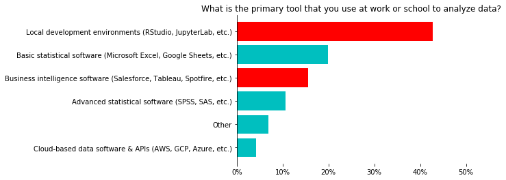

```python
# What is the primary tool that you use at work or school to analyze data?
plot_ans_14(ans_14)
```

## Why Tableau not other BI tools

- Tableau offers eduction licenses for both students and instructors
- Tableau is cross-platformed
- Tableau is one of the most popular BI tools in industry

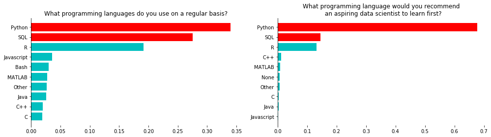

```python
# What programming languages do you use on a regular basis?
# What programming language would you recommend an aspiring data scientist to learn first?
plot_ans_18_19(ans_18, ans_19)
```

## Why SQL and Python

The plots speak loud and clear.